# DTRA-NK Livestock Movement Data

Sirimon Thomas

2024-06-18

[figure not shown]

This document presents the data from the short term GPS collars deployed by the DTRA-NK project in Samburu, Marsabit and Turkana counties.

For each tracked animal, a Home Range (HR) and Core Utilisation Distribution (CUD) have been calculated based on the 95th and 50th isopleth, respectively. These have been calculated using two methods:

1. Minimum Convex Polygon (MCP) - this is the smallest polygon with all internal angels less that 180deg that covers all the points. This is the simplest method and is used by IUCN for home range estimation.
2. Kernel Density Estimation (KDE) - this employs smoothing function to define space utilisation and the HR and CUD are calculated from this model.

Both these methods assume independence of points, which is violated in this data due to the high frequency of location fixes (every 10 seconds). This will be corrected by using Autocorellated Kernel Density Estimation in the future.

Additional statistics such as distance travelled, average speed and time of collar deployment are also presented.

## GPS statistics

Average GPS statistics for tracked animals, by species

| Species | CUD by KDE (ha) | HR by KDE (ha) | CUD by MCP (ha) | HR by MCP (ha) | Distance traveled (km) | Time with collar (h) | Mean speed (km/h) | Number of animals |
| --- | --- | --- | --- | --- | --- | --- | --- | --- |
| camel | 108.03 | 501.46 | 210.79 | 362.97 | 18.92 | 40.04 | 0.48 | 11 |
| cattle | 52.34 | 248.16 | 49.83 | 193.97 | 16.22 | 42.23 | 0.38 | 11 |
| goat | 59.87 | 295.50 | 91.42 | 193.63 | 15.21 | 42.73 | 0.35 | 10 |
| sheep | 26.83 | 118.39 | 51.81 | 91.45 | 9.98 | 31.49 | 0.36 | 10 |

## HR and CUD maps by species

### Goat

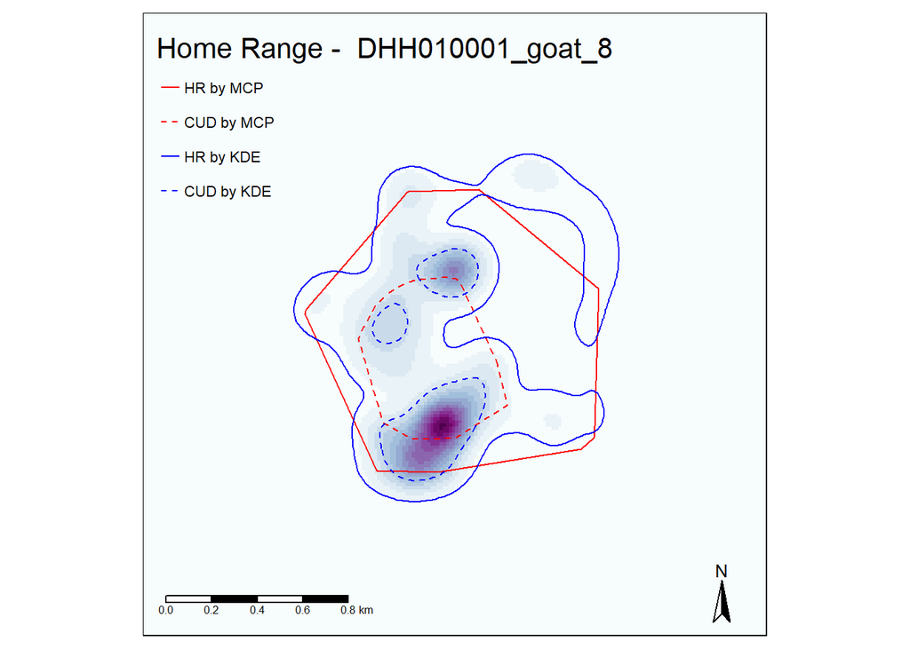

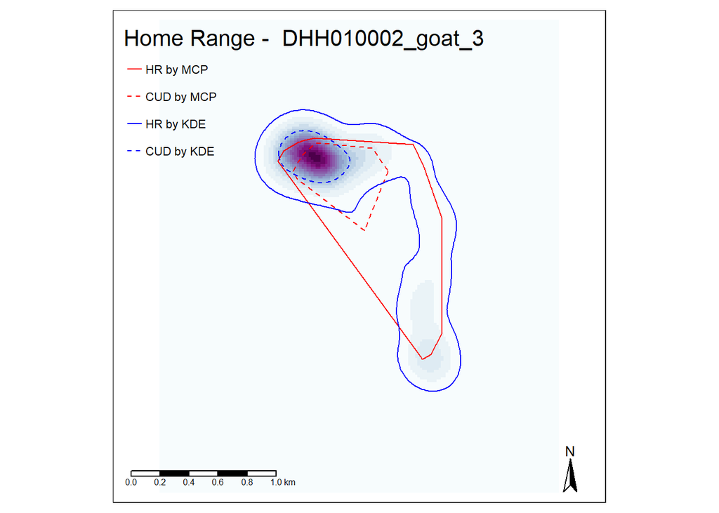

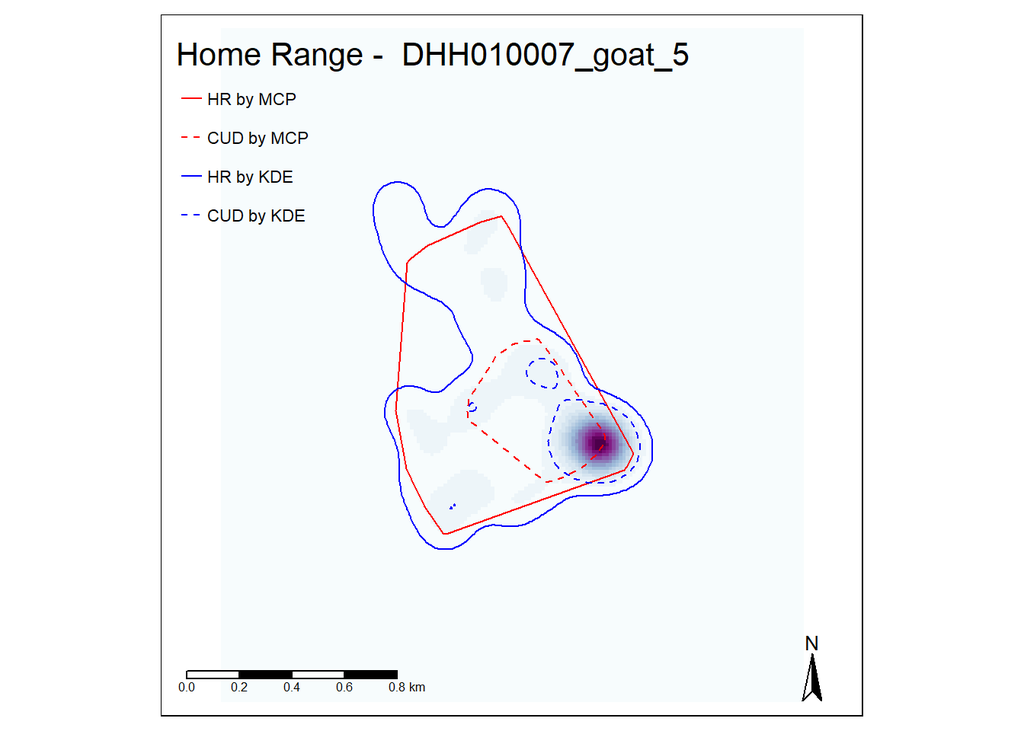

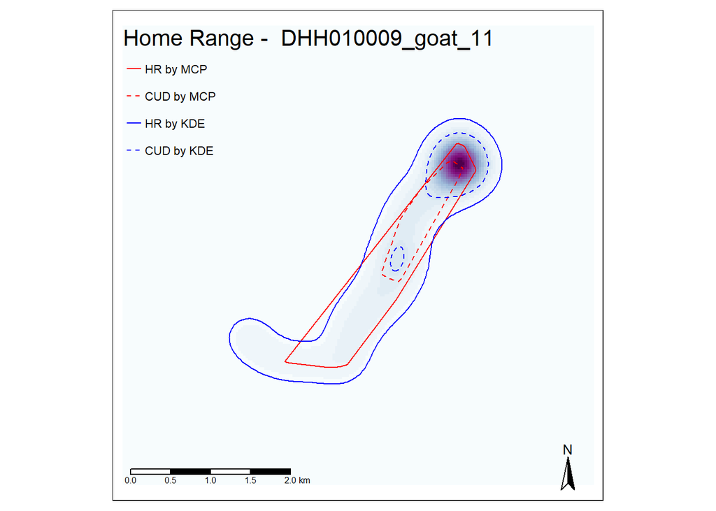

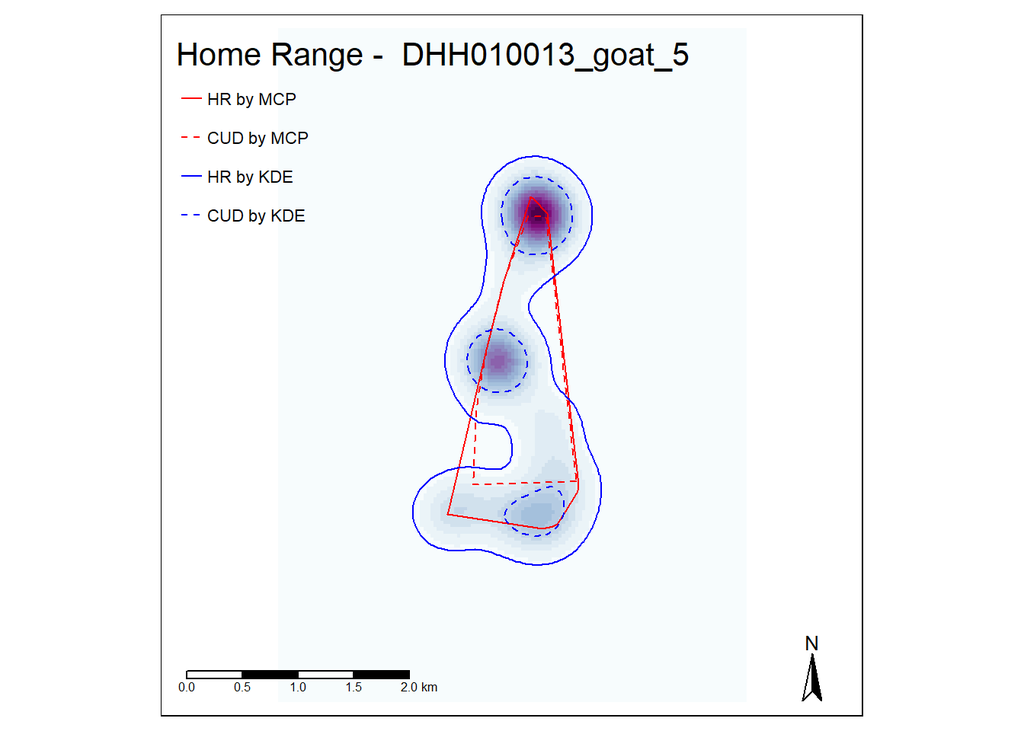

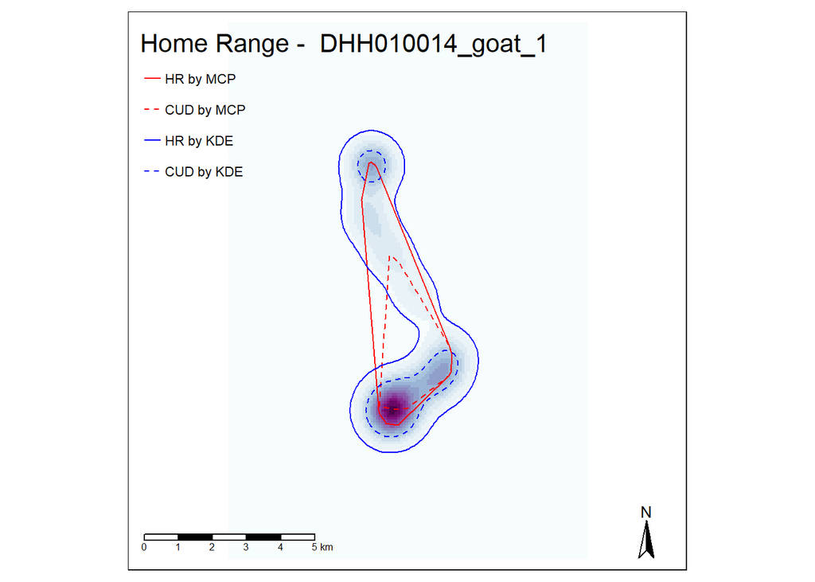

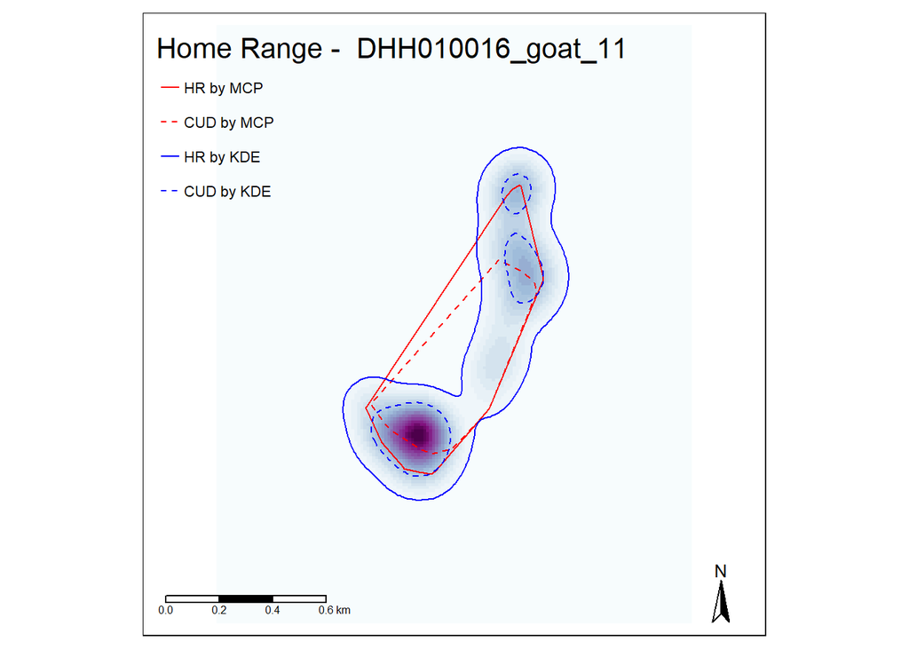

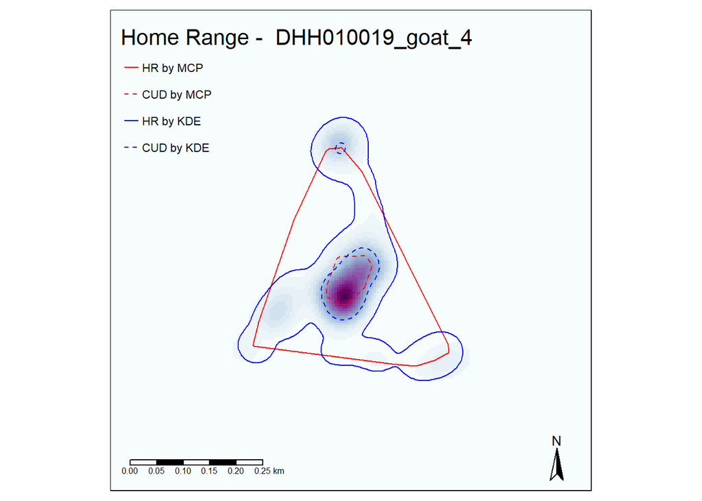

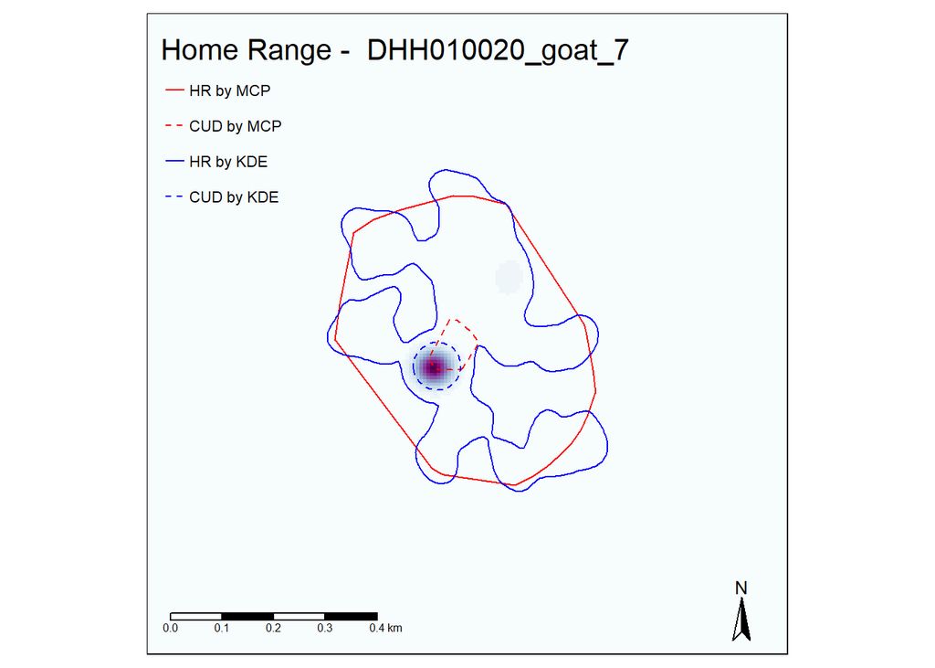

### Sheep

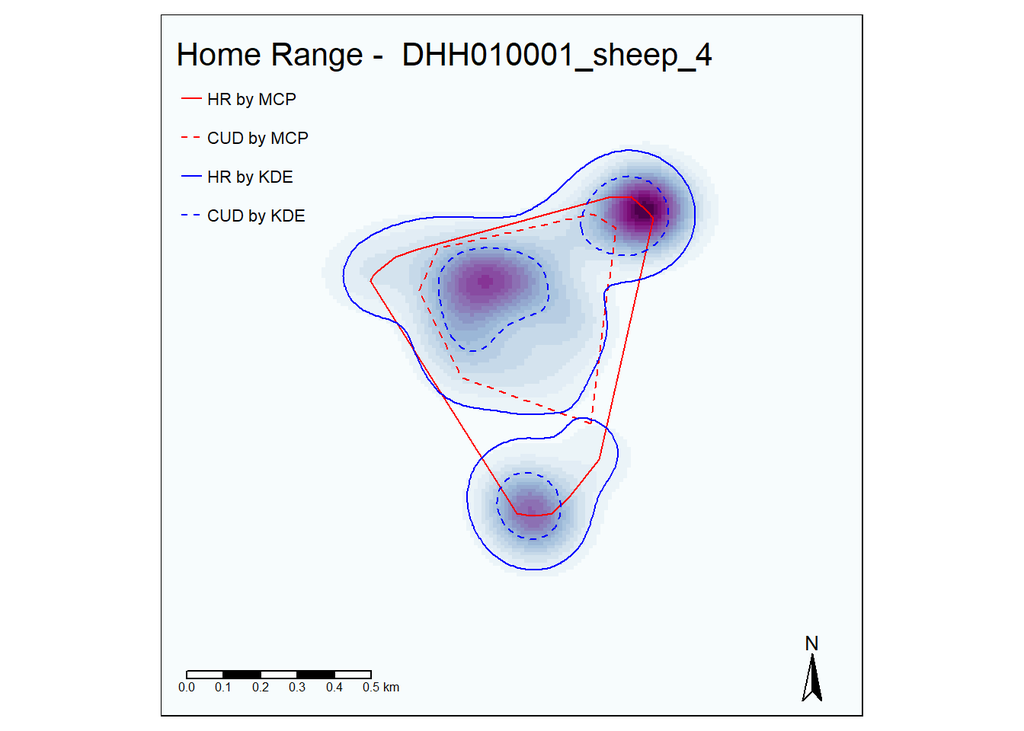

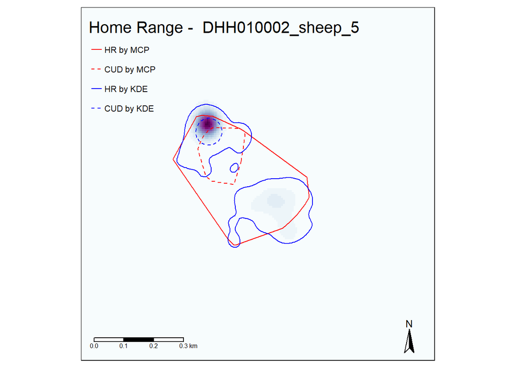

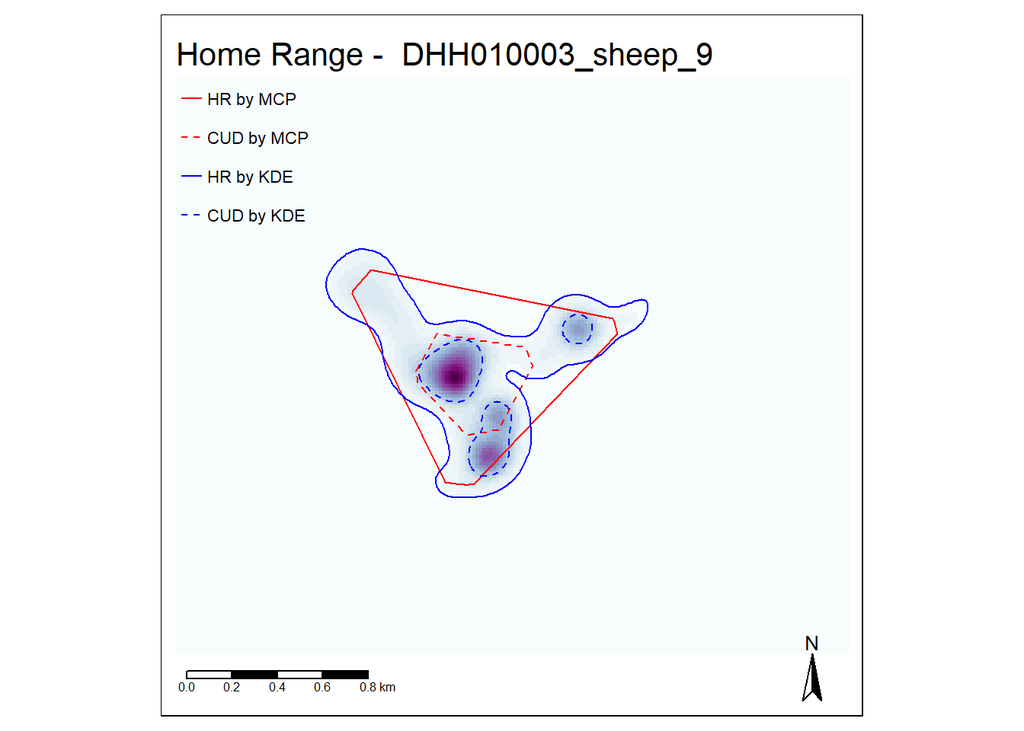

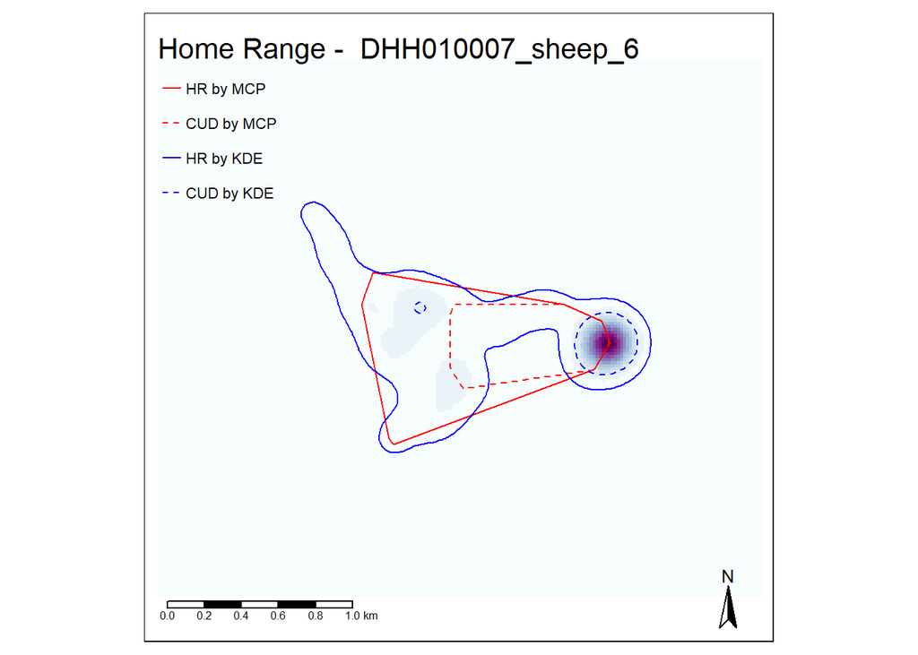

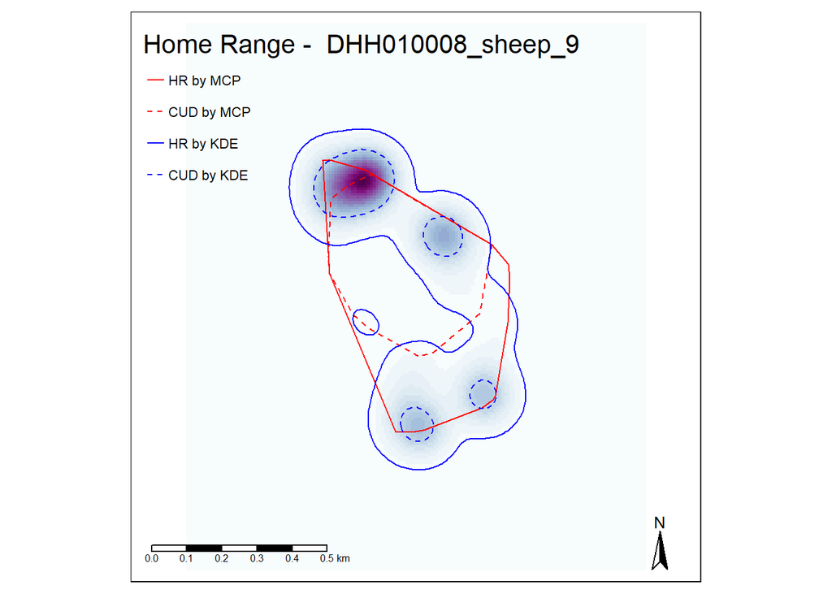

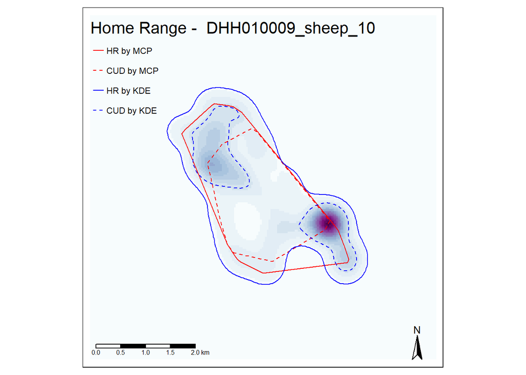

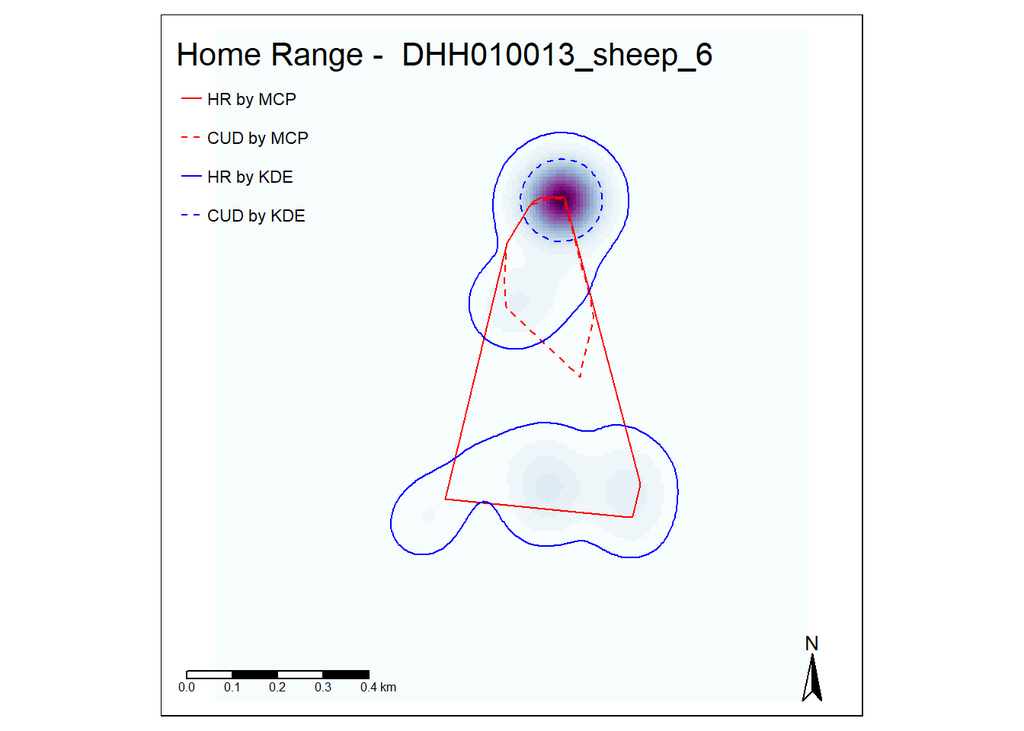

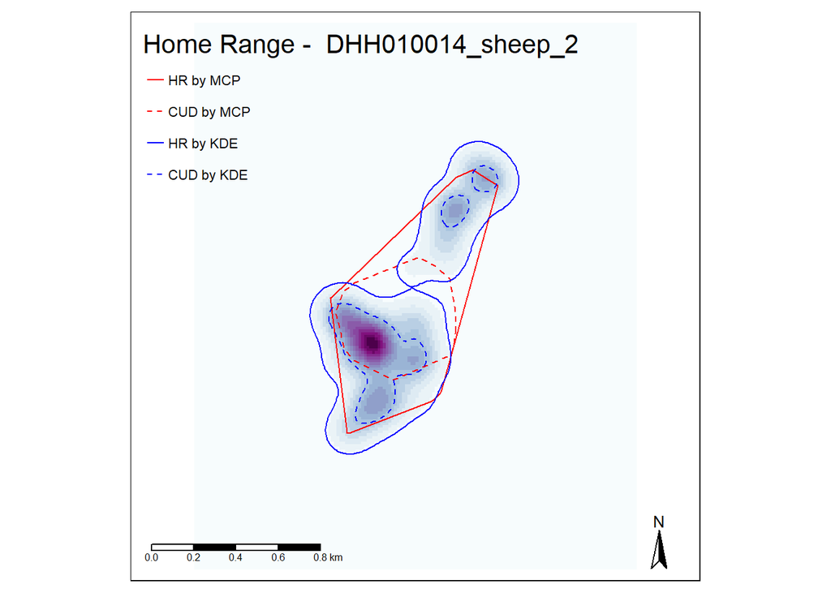

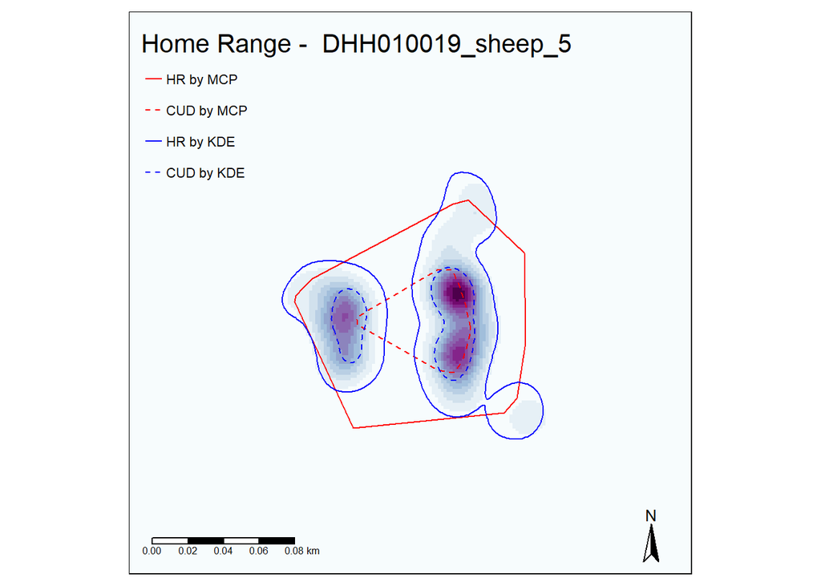

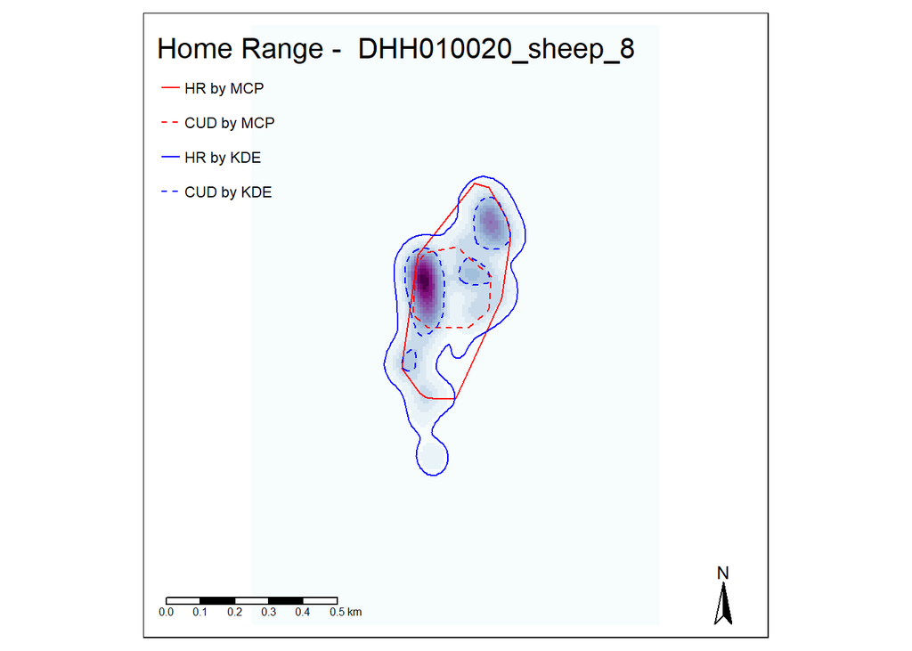

### Camel

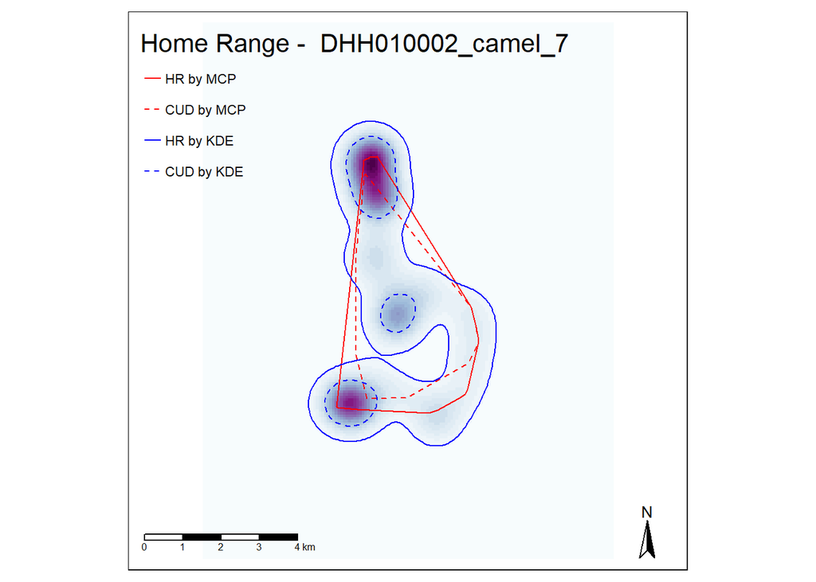

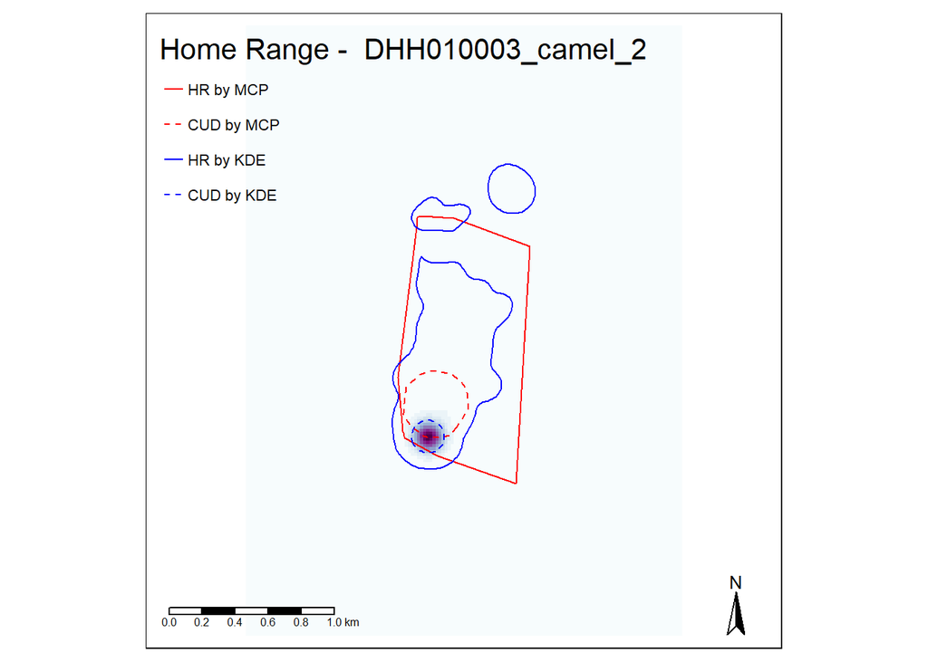

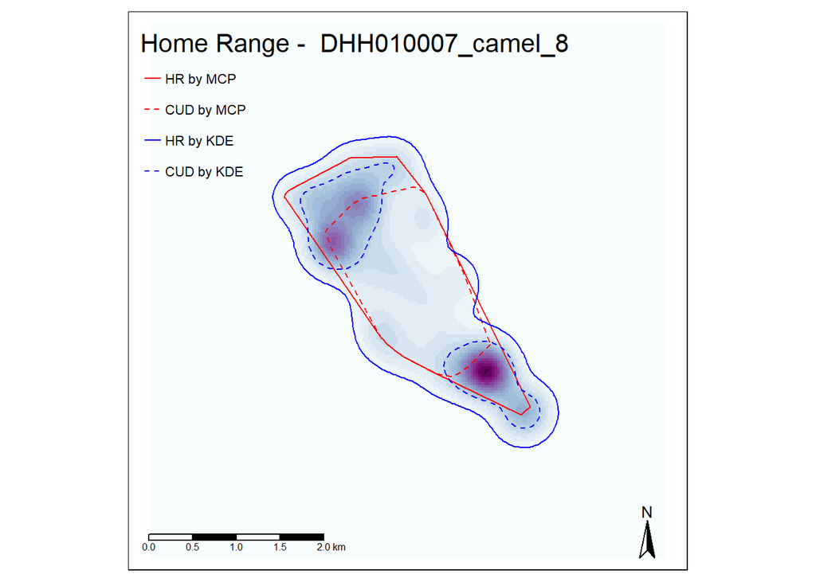

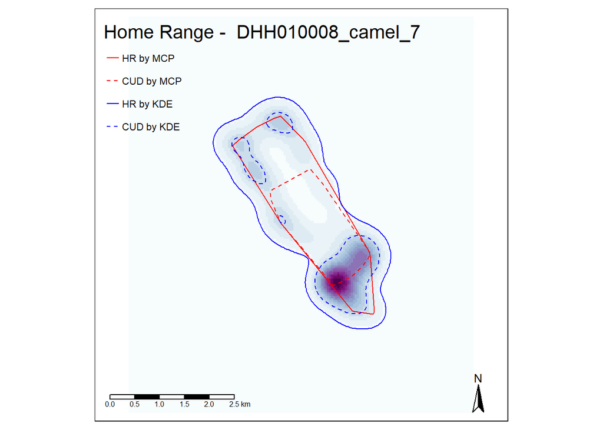

[figure not shown]

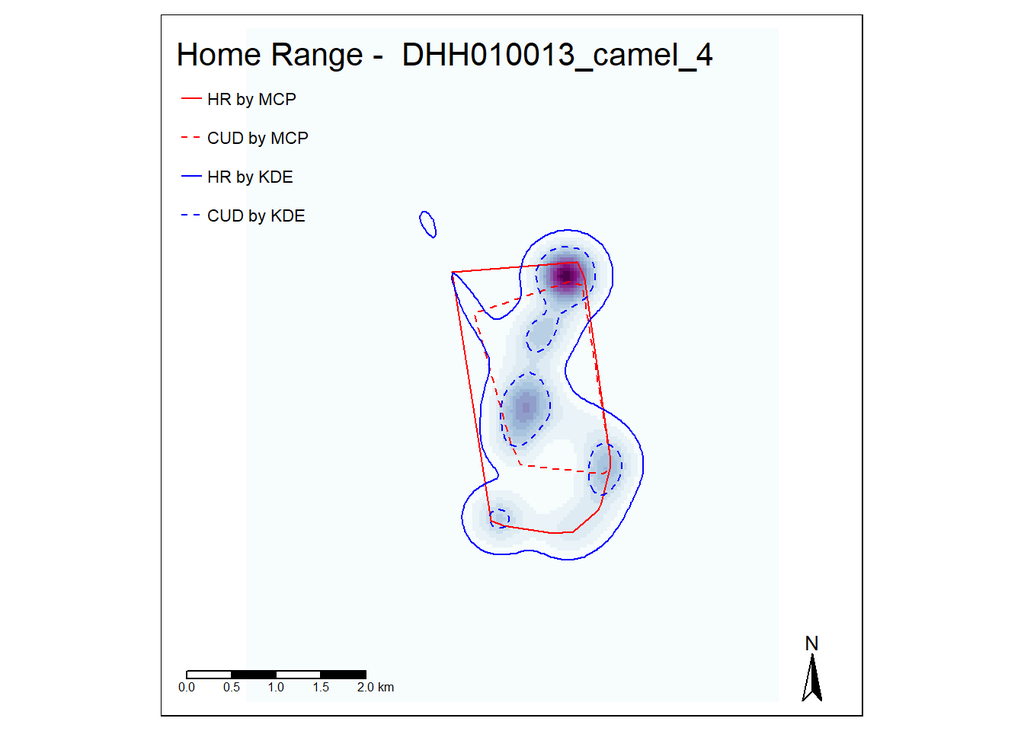

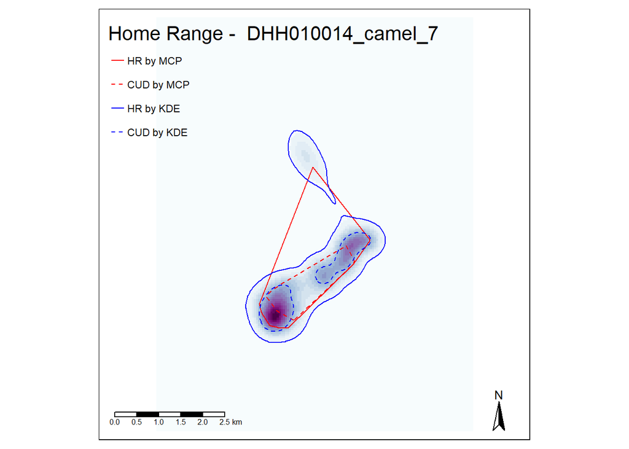

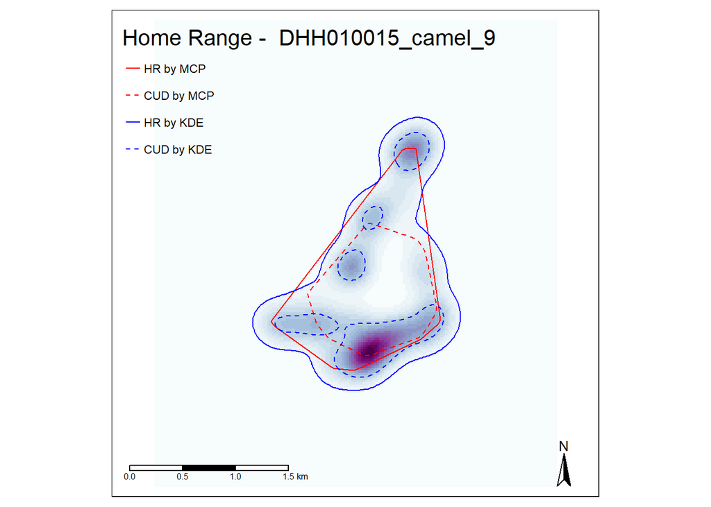

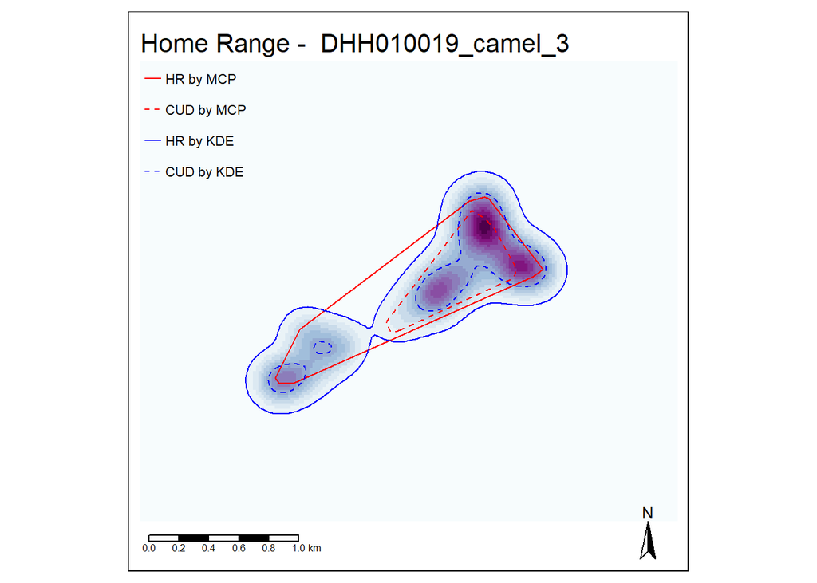

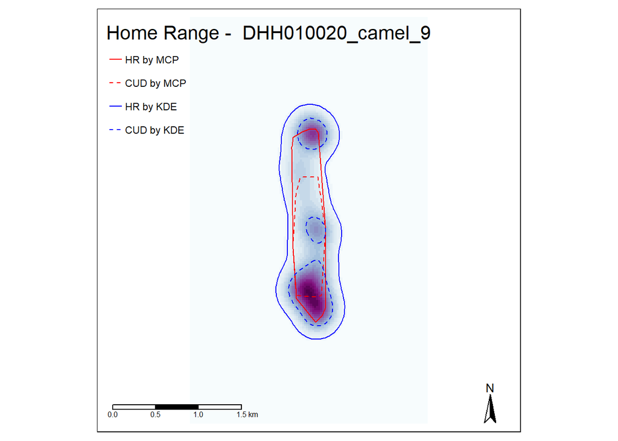

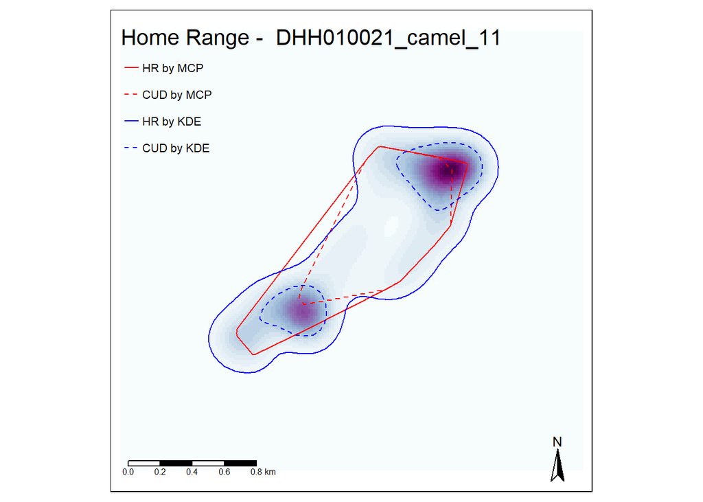